# TCGA-BRCA Genomic Analysis

## Mutation Landscape

### MAF Summary

Overview of variant classifications, types, and SNV classes across the cohort.

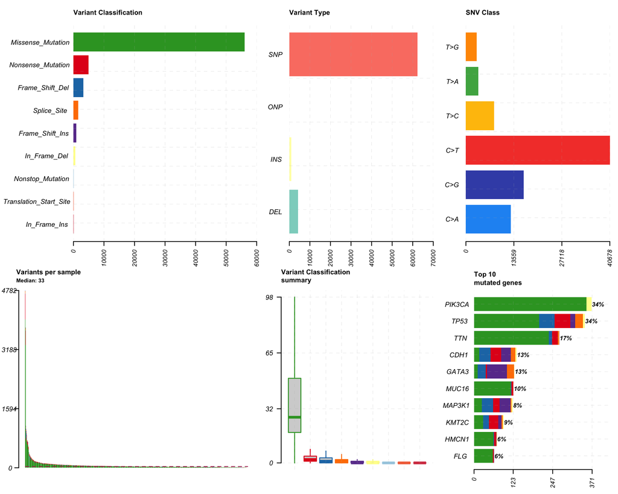

```r
plotmafSummary(maf, rmOutlier = TRUE, addStat = "median")
```

### Oncoplot — Top 20 Mutated Genes

Each column is a patient, each row is a gene. Colors indicate mutation type. TP53 and PIK3CA dominate at 34% each, consistent with published TCGA-BRCA findings. CDH1 (13%) marks the lobular subtype; GATA3 (13%) marks luminal tumors.

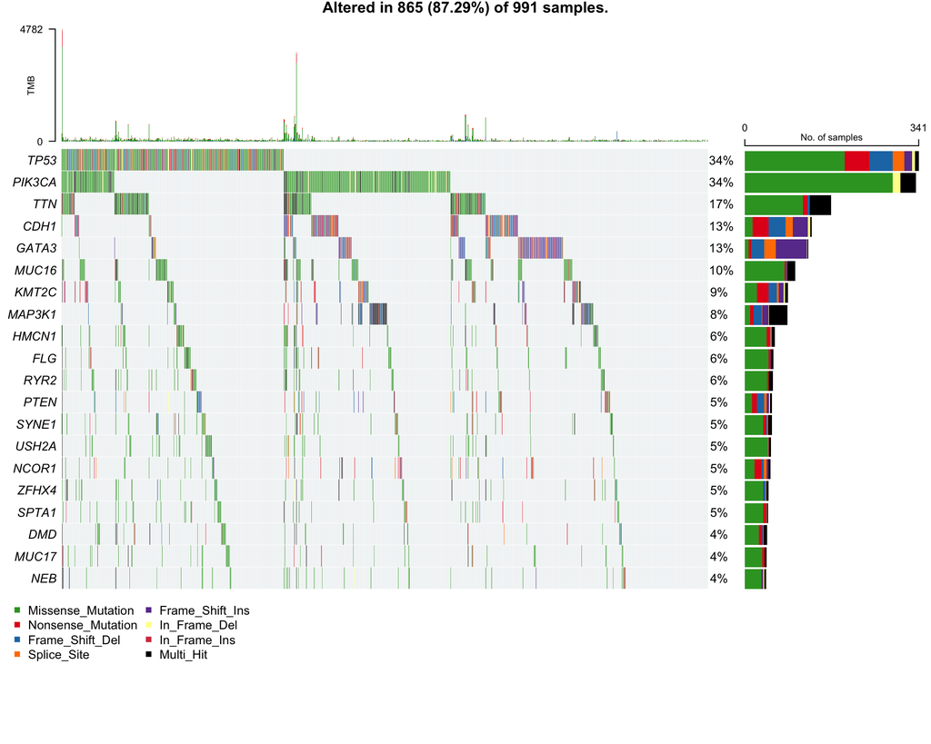

```r
oncoplot(maf = maf, top = 20)
```

## Survival Analysis

### Stage vs Overall Survival

Kaplan-Meier curves stratified by AJCC pathologic stage. Stage is a highly significant predictor of overall survival (log-rank p < 0.0001), with Stage IV patients showing rapid early mortality.

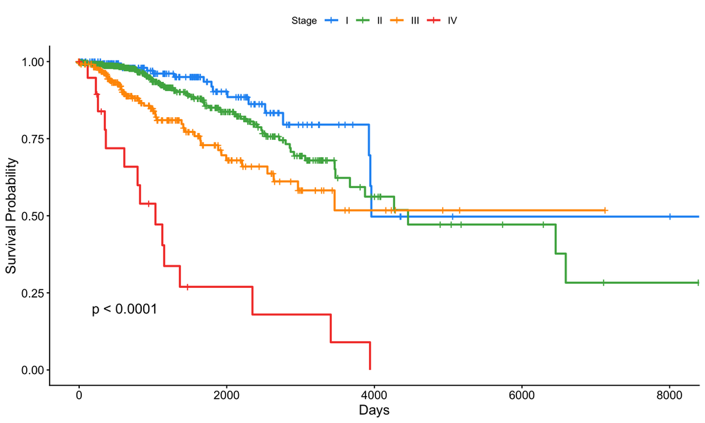

```r
fit_stage <- survfit(
    Surv(overall_survival_days, vital_status) ~ stage_group,
    data = patient_summary %>% filter(!is.na(stage_group))
)

ggsurvplot(
    fit_stage,
    data    = patient_summary %>% filter(!is.na(stage_group)),
    pval    = TRUE,
    palette = c("#2196F3", "#4CAF50", "#FF9800", "#F44336"),
    legend.title = "Stage",
    legend.labs  = c("I", "II", "III", "IV"),
    xlab = "Days",
    ylab = "Survival Probability"
)
```

### TMB Distribution

Tumor mutation burden is log-normally distributed and centered around 1 mut/Mb — typical for breast cancer, a tumor type with low mutational burden compared to melanoma or lung cancer. The dashed lines show the 5 and 20 mut/Mb thresholds used in literature.

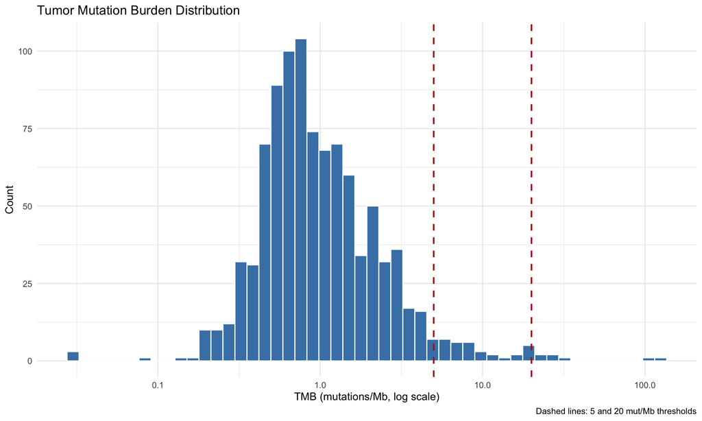

```r
patient_summary %>%
    filter(!is.na(tmb)) %>%
    ggplot(aes(x = tmb)) +
    geom_histogram(bins = 50, fill = "steelblue", color = "white") +
    geom_vline(xintercept = c(5, 20), color = "firebrick",
               linetype = "dashed", linewidth = 0.8) +
    scale_x_log10() +
    labs(
        x = "TMB (mutations/Mb, log scale)",
        y = "Count",
        title = "Tumor Mutation Burden Distribution",
        caption = "Dashed lines: 5 and 20 mut/Mb thresholds"
    ) +
    theme_minimal()
```